# Ottawa’s 85 Year Temperature Report

**What’s Happening with Ottawa’s Temperature?**

Author

John Lewis

Published

June 14, 2026

## 1 Executive Summary

“Extreme anomaly frequency by decade”. This figure Figure 1 shows that Ottawa’s climate is not just shifting in its average but that the nature of its extreme events has flipped. The crossing of the cold (blue) and warm (red) extreme frequency lines in the late 1980s is an intuitive indicating that the baseline climate has fundamentally changed.

Together, these two graphs tell the essential story that warming has structurally shifted gears around 1997, and the consequence is a redistribution from cold temperature extremes toward heat extremes which is already underway.

## 2 Introduction

“The world has been heating up for the past 100 years or so. As a result weather patterns are changing” (A really simple guide to climate change: 14 Jan. 2026, BBC.com/news). As evidence, recent climate headlines have stated “*The Pace of Climate Change Has Almost Doubled in Ten Years*” , “*Climate: Which cities saw record heat last year?*” or “*Have We Crossed a Dangerous Warming Threshold? …*”. Further to this many climate scientists have written that global temperatures in 2025 averaged 1.47 degrees above pre-industrial levels which is uncomfortably close to a key benchmark of 1.5 degrees Celsius for global atmosphere temperatures. The earth is warming at a rate of $0.35 ºC$ per decade, nearly double the rate of $0.2 ºC$ per decade in the 1970s. (Nature | Vol 651 | 19 March 2026) Copernicus, a European Climate Change Service, has found that last year was the third-warmest year on record, after **2024** and **2023** and along with **2016** as one of the warmest years this century. The trend is clear that the last 11 years have been the 11 hottest since Copernicus started keeping records in 1950. Given these concerns let’s look at how Ottawa fits into the global and northern hemisphere temperature pattern.

## 3 Data sources

Ottawa annual and monthly temperatures, for a time span of 85 years (1940-2024), were downloaded from the Environment Canada website.

| Variable | Source | Period | Resolution |
| --- | --- | --- | --- |
| Ottawa | Environment Canada (OTTAWA MACDONALD-CARTIER INT’L A) | 1940-2024 | Daily |
| Northern Hemisphere | HadCRUT5.1 (nh_ann.csv) | 1940-2024 | Annual |
| Global | HadCRUT5.1 (global.annual.csv) | 1940-2024 | Annual |

Ottawa temperature anomalies are computed as deviations from the 1940-2024 monthly climatological mean for each calendar month. Winter seasons span December,January,February (DJF), with December associated with the following calendar year (e.g., December 1999 belongs to Winter 2000).

## 4 Ottawa Annual Temperature Overview

**Ottawa Temperature 1940-2024**

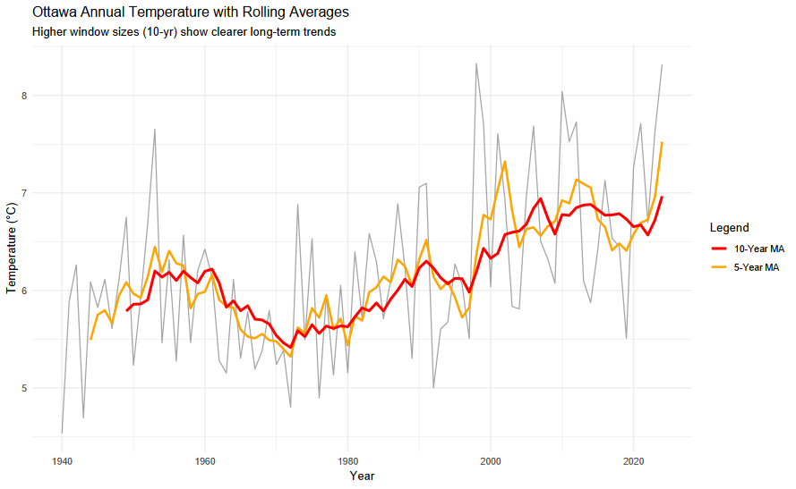

By dealing with deviations ($x_i - \bar{x}$) rather than raw values, there is a shift in the focus from the scale of the data to the relationships within it. So all of the following graphs of temperature will be plotted as deviation form the mean or trend (anomalies). Also this is the method used in the recording procedure for the Global and Northern Hemisphere long term temperature data.

**Trend Analysis of Ottawa Annual Temperature**

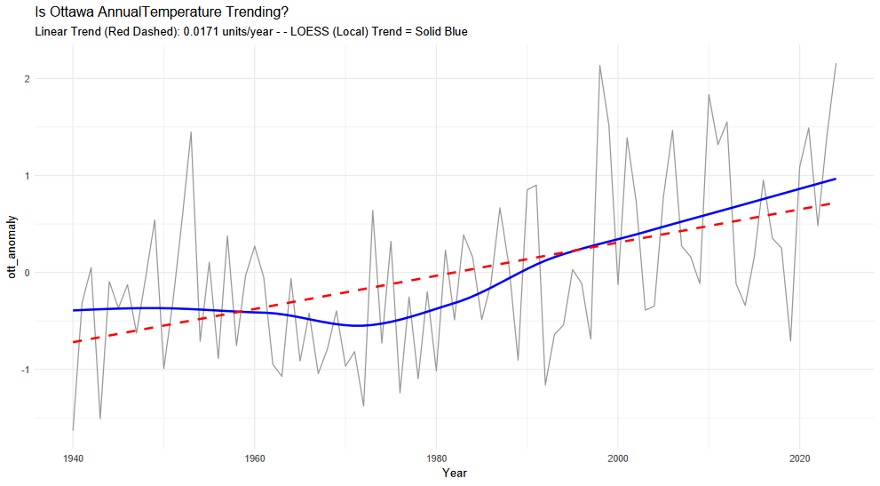

This above plot focus on the annual temperatures statistical trends for Ottawa from 1940 to 2024. The two obvious observations are the upward trend in the data during this 85 year period shown in both the linear trend and the local regression non-linear trend (blue line). Notice the dip in the local trend line indicating a cooler period from the early 1950s to the mid 1980s with an increasing rate of warming after those dates. This was mentioned previously but is more visually apparent on thiss plot. As we shall see, this is the general trend of the temperature pattern for both the Northern Hemisphere and the Global temperatures series.

## 5 Inter Annual Temperature Variability

```
[1] "The Interannual Variability is: 0.755"
```

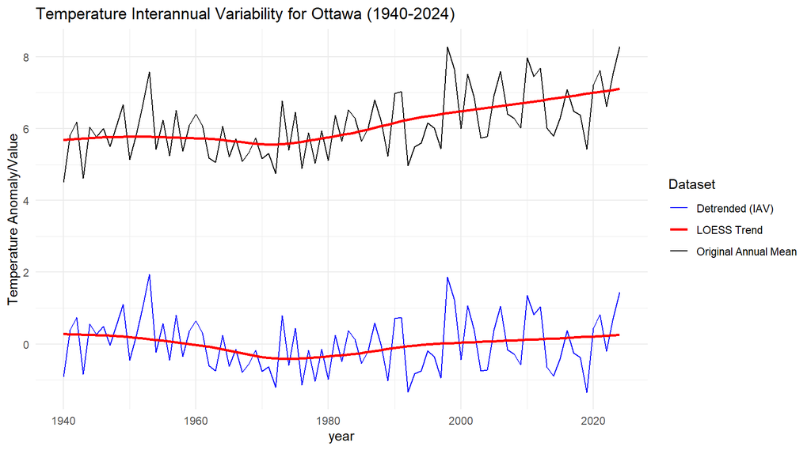

The “variability” is the noise around the signal. If the time series is not detrended, a steady warming trend will be incorrectly interpreted as high interannual variability. If a city warms by $2^\circ\text{C}$ over 85 years perfectly smoothly, the standard deviation would be high, but the interannual variability (the “bounce” from one year to the next) would actually be zero. Using detrend() ensures you are measuring the year-to-year swings rather than the multi-decadal climate shift.

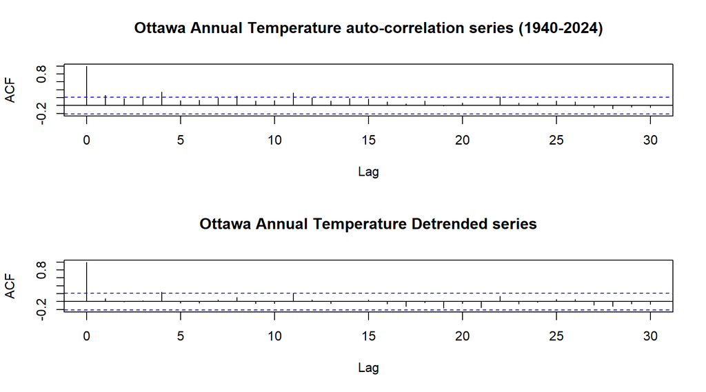

## 6 Monthly Temperature

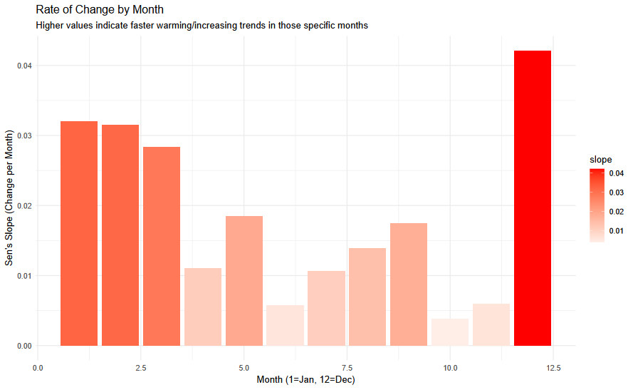

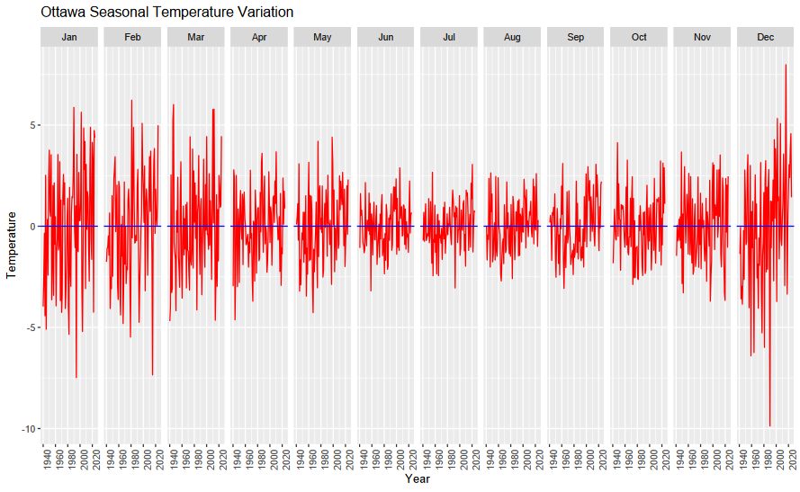

What to look for in these two plots: 1) Trends: Do you see higher red bars toward the begining and ending of the yearly period? That indicates a long-term warming or increasing trend in those months. 2)Volatility: Are some months (like January and December) much more “jumpy” than others (like July) indicating different degrees of variabilityty?

Trend (Slope) Values for Ottawa Winter Temperature for each Momth

[output not shown]

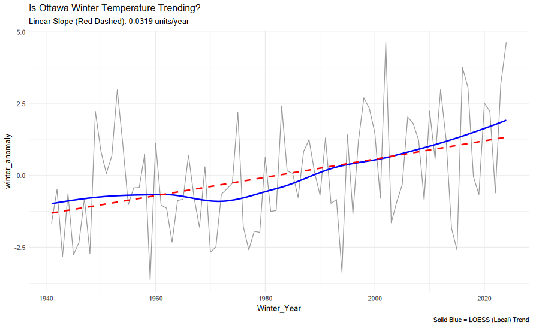

The overall trend in winter (DJF) temperature of 0.032°C was found to be statistically significant ($p < 0.01$), suggesting a robust shift in the regional winter climate baseline for Ottawa. This is especially true for the month of December where the warming rate is 0.042°C per year which is very statistically significant (p < 0.001).

## 7 Decadal Temperature Trends

Investigating the temperature series at the decade levels provides insight into the climatic regime patterns.

Ottawa Decade Temperature Trends

Decadal averages and climate volatility (SD)

| Decade | Avg Temp (°C) | Volatility Index |
| --- | --- | --- |
| 1940 | −0.41 | 0.68 |
| 1950 | −0.12 | 0.77 |
| 1960 | −0.54 | 0.48 |
| 1970 | −0.57 | 0.68 |
| 1980 | −0.15 | 0.56 |
| 1990 | 0.23 | 1.07 |
| 2000 | 0.38 | 0.68 |
| 2010 | 0.52 | 0.85 |
| 2020 | 1.33 | 0.61 |

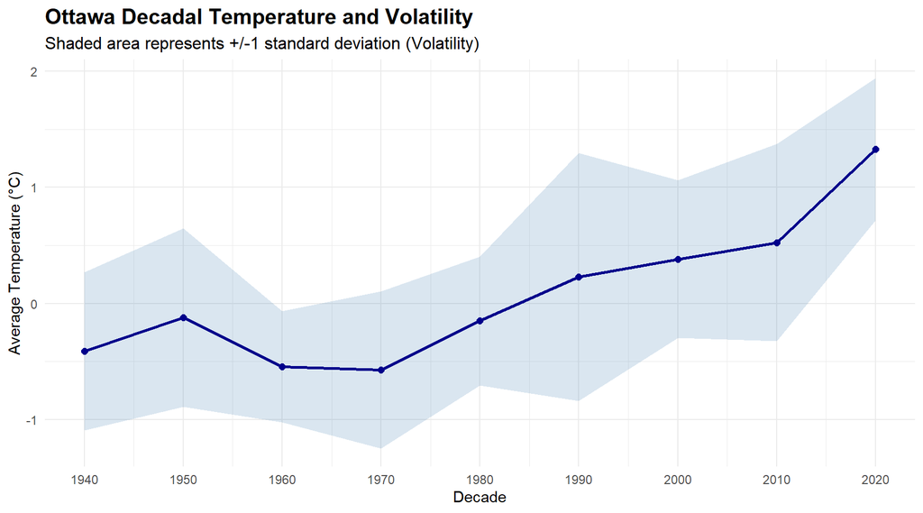

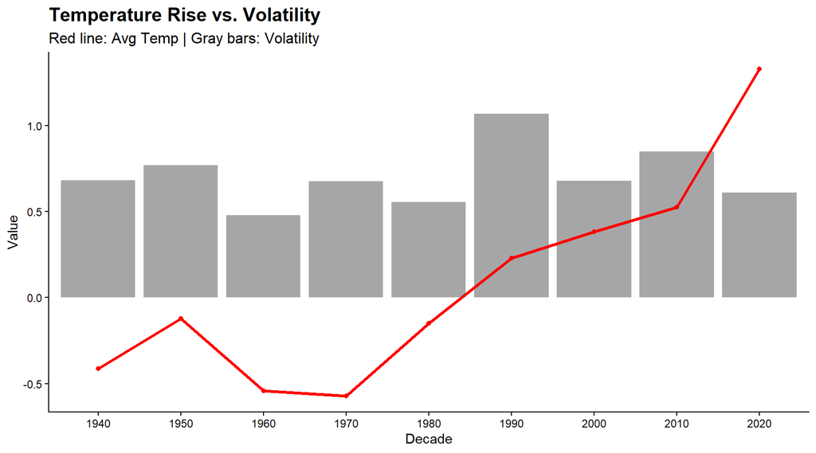

Contextualizing the 1.33°C: In the 2020s, the data shows a massive jump. A plot makes this “hockey stick” shape immediately visible compared to the -0.413°C of the 1940s.

Volatility Insights: Notice in the data that while temperatures are rising steadily, whereas volatility behaves differently (e.g., that big spike in the 1990s) with the volatility peaking at$ +/-1.07 ºC$. The information on the above plot begs the question as to why that decade was so much more unstable than the 2020s, even if the 2020s are warmer.

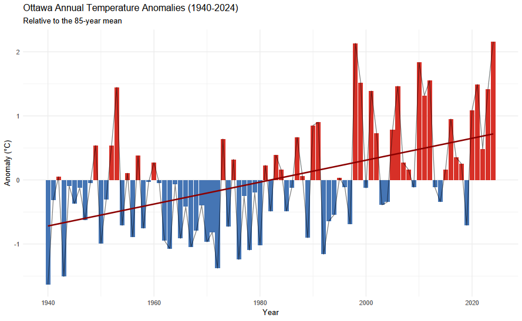

Figure 1: Extreme temperature anomaly frequency by decade (1940–2024)

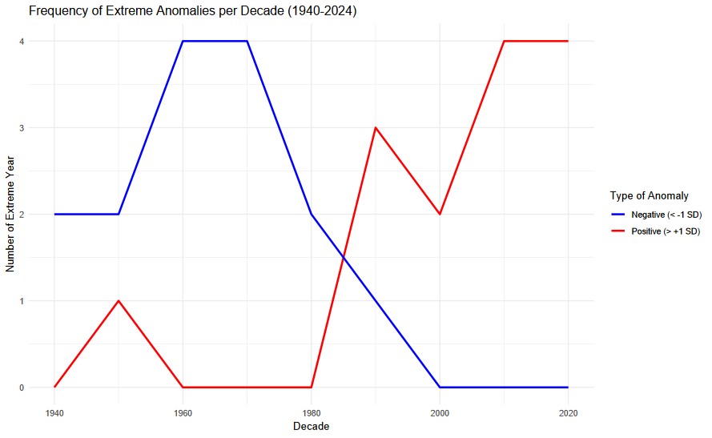

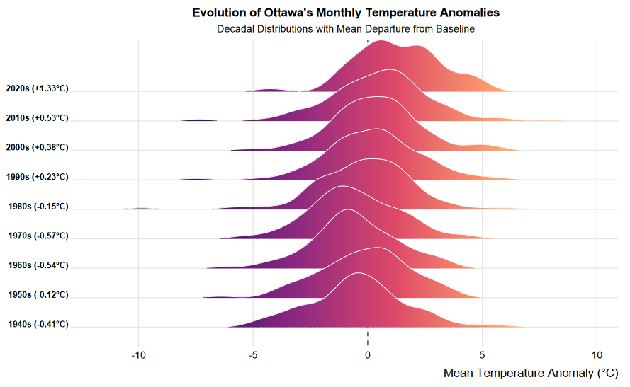

Notice the change in the density distribution as time moves closer to the present - the right tail of the distribution, starting the the 90s, gets longer. This indicates that there are more extreme temperatures occurring. However, the 1990s had significant outliers to the left of the distribution too. A highly volatile decade.

## 8 Change point detection - shifts in Ottawa’s Temperature

### 8.1 Is there a structural (regime) change in Ottawa’s historical temperature?

A strategy for long-term temperature data is to attempt to find true structural shifts (like climate regime shifts or even sensor changes). A nonparametric approach should be used which avoids assuming the temperature follows normal distribution (a bell shape curve), where many times the data often doesn’t.

Climate data is notoriously “noisy” due to seasonality (summer vs. winter) and local weather fluctuations. If you run a standard change point detection on the daily or monthly data, the algorithm will likely get “distracted” by the seasonal swings and identify a change point every six months. Therefore to examine the possibility of structural changes in the climate, we will look at the annual temperature series for Ottawa rather than other time perioderiods.

The statistical procedure for detecting structural changes is a change point algorithm developed by R. Killick and her colleagues (Ref and R package). The model used in this analysis employs a penalized likelihood approach to detect structural change-points in the temperature series which includes shifts in the mean, trend shifts and changes in the variance and uses the Bayesian Information Criteria (BIC) to indicate the optimal structural breakpoints.

Structural Breakpoint Analysis

Breakpoint years by number of segments (m) and associated BIC

| Number of Breaks | BIC Score | BP 1 | BP 2 | BP 3 | BP 4 | BP 5 |
| --- | --- | --- | --- | --- | --- | --- |
| m = 1 | 200.09 | - | - | 1997 | - | - |
| m = 2 | 206.55 | - | 1980 | 1997 | - | - |
| m = 3 | 211.82 | 1961 | 1980 | 1997 | - | - |
| m = 4 | 220.11 | 1961 | 1980 | 1997 | 2012 | - |
| m = 5 | 228.88 | 1951 | 1964 | 1980 | 1997 | 2012 |

Note: Bold BIC indicates the optimal model according to the Bayesian Information Criterion.

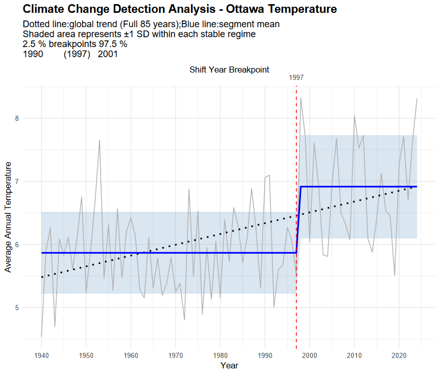

What this plot tells us is that if the ribbon jumps up significantly, you’re seeing a clear “regime shift” where the new normal is entirely outside the old normal’s typical range.If the ribbon gets wider after a change point, it means the climate became more volatile (higher variance) in that segment, even if the average temperature didn’t change much.

Figure 2: **Is there an acceleration of warming in Ottawa’s Temperature Regime?**

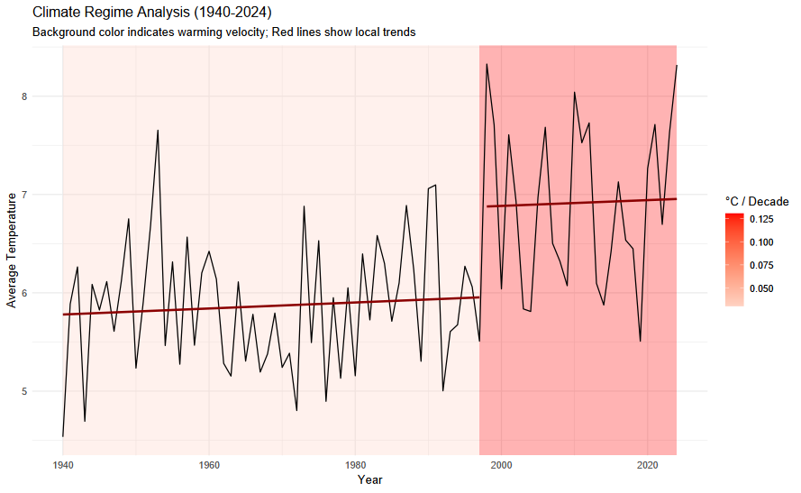

A “Segmented Trend” model recognizes that the climate is a moving target. If the red lines are getting steeper with later segments, you have clear evidence of climate acceleration.

##### 8.1.0.1 Interpreting “Acceleration”-look at the slope column in the table below:

| Segment | Start | End | Slope |
| --- | --- | --- | --- |
| 1 | 1940 | 1997 | 0.0031 |
| 2 | 1997 | 2024 | 0.0130 |

In visualizing global vs. local trends, one really see the difference. It’s helpful to plot the individual segment slopes against a single trend line for the entire 85-year period.

## 9 Temperature Comparison of Ottawa with Northern Hemisphere and Global series

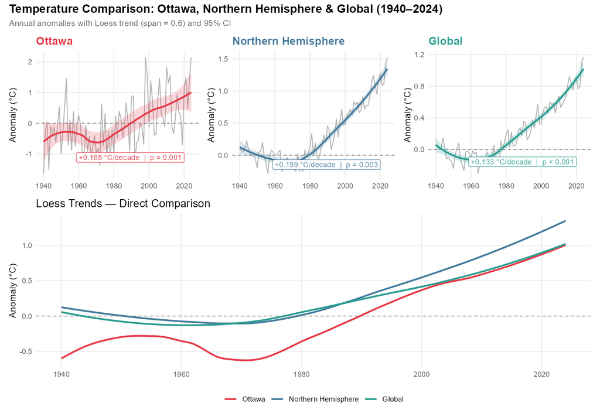

Figure info: Annual temperature anomalies (1940–2024) for Ottawa, Northern Hemisphere, and Global series. Top row: individual series with Loess trend (coloured line) and 95% CI (shaded ribbon). Bottom panel: all three Loess trends overlaid for direct comparison

Long-term Warming Trends (1940–2024)

Sen's slope with Modified Mann-Kendall significance test

| Series | Sen's Slope (°C/decade) | *p*-value (MMK) |
| --- | --- | --- |
| Ottawa | 0.168 | 0.001 |
| Northern Hemisphere | 0.159 | 0.003 |
| Global | 0.133 | < 0.001 |

Modified Mann-Kendall test corrects p-values for autocorrelation.

Ottawa’s warming rate of +0.168°C/decade is approximately 27% faster than the global rate of +0.133°C/decade, consistent with the well-documented pattern of amplified warming in continental interiors and higher latitudes.In part, that is the reason that the rate change of temperature for the Northern Hemisphere in closer to the Ottawa value than the global.

## 10 Summary

#### 10.0.5 **Comparative Trends (1940–2024)**

Ottawa’s data looks like a “heart monitor” (high volatility) compared to the smoother NH line. The reason for this is that NH averages smooths out local extremes by averaging oceans and continents together. Ottawa’s reality is that being in a continental interior, Ottawa is subject to massive swings—the loss of “extreme cold” years is actually one of the biggest drivers of the warming trend in Ottawa’s temperature data.

It is fascinating to see that the data confirm what many long-time residents suspect and that is, Ottawa climate is changing significantly due to the addition of greenhouse gases but alos, highlighting the continued influence of stochastic weather patterns and atmospheric teleconnections.

Disclosure: The AI Gemini help in the restructing of the Summary and helped correct some of the R code that produce the graphs. In addition, it offered suggestions on different way for the research to proceed.